# PCA for Movies, The data source: IMDB

Marco Ayuob

2024-01-12

## Introduction

The main goal of the project is to gain a better understanding of the characteristics of movies and how they relate to each other by using statistical techniques and data visualization. This analysis can provide valuable insights for individuals involved in the movie industry, such as filmmakers, marketers, and distributors, to comprehend which factors contribute the most to a movie’s success and popularity. The project focuses on methodical data analysis and employs advanced techniques like PCA, making it a robust approach to understanding complex datasets in the entertainment domain.

```r
# Set the working directory and read the file
data <- read.csv("/Users/marcoayuob/Downloads/archive/movies_metadata.csv")
```

## Exploratory Data Analysis (EDA)

To begin, it’s important to visually analyze the data using histograms and boxplots for numerical variables like runtime and vote average. This initial step is critical in comprehending the distribution and scope of these variables. Furthermore, examining pairwise scatter plots offers valuable insight into the correlations between different pairs of variables.

```r
nrow(data)
```

```
## [1] 45466
```

```r
ncol(data)
```

```
## [1] 24
```

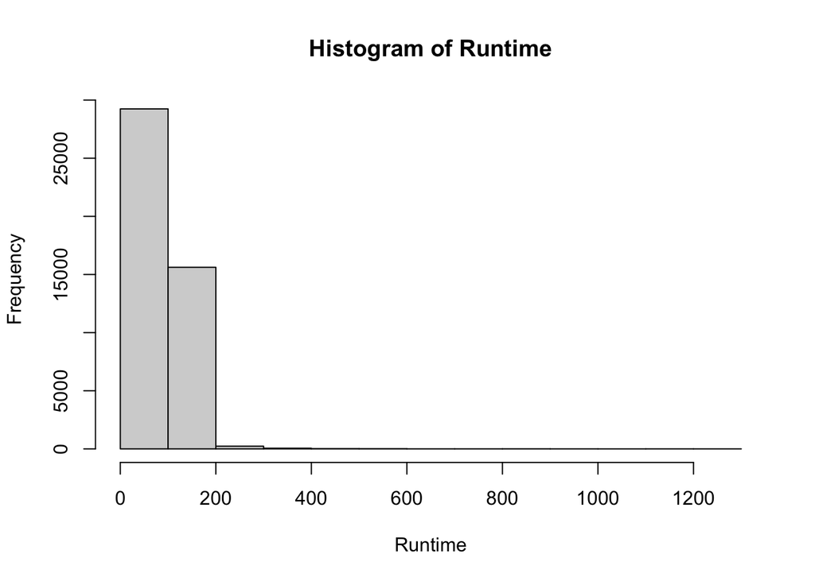

```r
# Histograms for numerical variables
hist(data$runtime, main = "Histogram of Runtime", xlab = "Runtime")
```

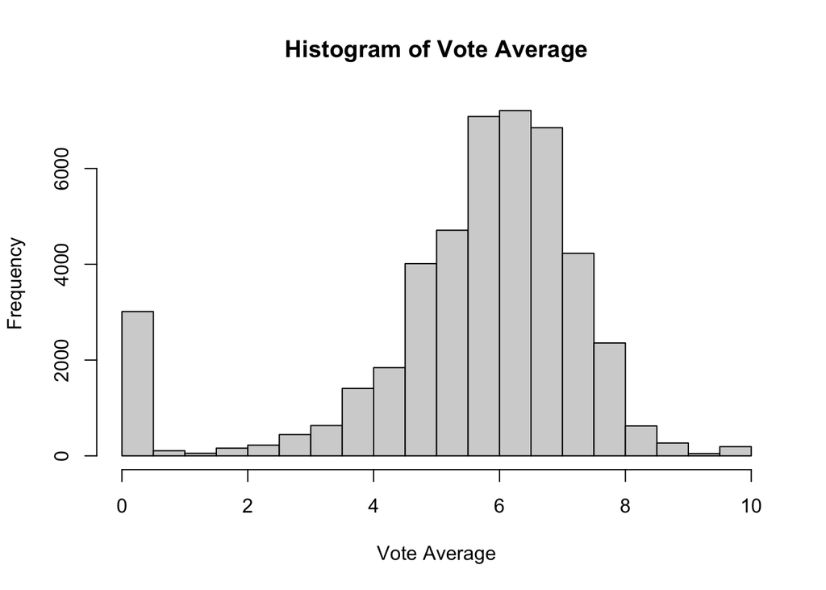

```r
hist(data$vote_average, main = "Histogram of Vote Average", xlab = "Vote Average")
```

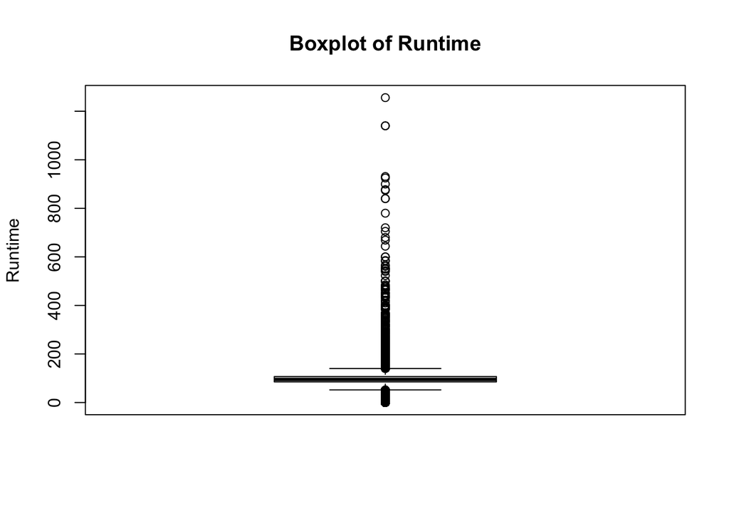

```r
# Boxplots for numerical variables
boxplot(data$runtime, main = "Boxplot of Runtime", ylab = "Runtime")
```

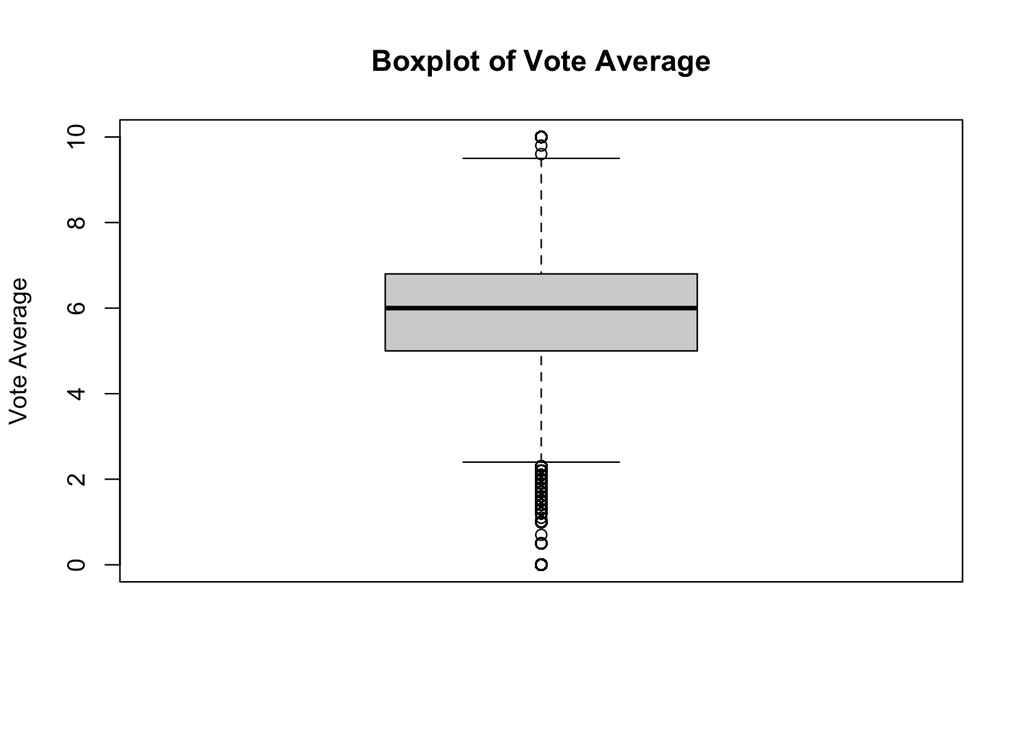

```r
boxplot(data$vote_average, main = "Boxplot of Vote Average", ylab = "Vote Average")
```